# Lab11

R Kelly

4/3/2019

```r
library(tidyverse)
library(babynames)
library(phonics)
srcbabynames<-(babynames::babynames)
```

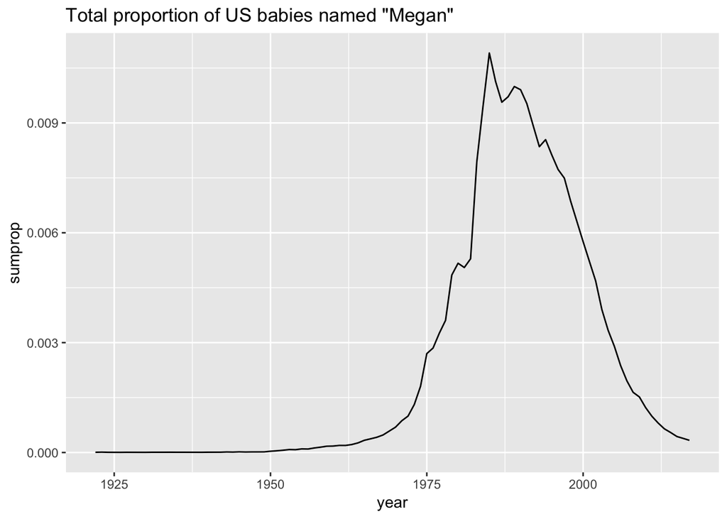

```r
#make your own version of the data by assigning a new variable to the srcbabynames data object
babynamesPersonal <- srcbabynames
babynames<-(babynames::babynames)
Megan <- filter(babynames,str_detect(babynames$name, "Megan")) %>% group_by(year) %>% summarize(sumprop=sum(prop))

ggplot(data=Megan) +
  geom_line(aes(x=year,y=sumprop)) +
  ggtitle("Total proportion of US babies named \"Megan\"")
```

# Team

```r
#Ariel and Rachel Code
Regex_1973 <- filter(babynames, year == 1973 )
Ariels1973 <- mutate(Regex_1973, containsName = str_detect(Regex_1973$name,"Ar[ie]")) %>% filter(containsName == TRUE)
#look for regex combining beginning of name and adding end condition


Regex_1988 <- filter(babynames, year == 1988 )
Ariels1988 <- mutate(Regex_1988, containsName = str_detect(Regex_1988$name,"Ari[el]")) %>% filter(containsName == TRUE & sex == "F")




Regex_1990 <- filter(babynames, year == 1990 )
Ariels1990 <- mutate(Regex_1990, containsName = str_detect(Regex_1990$name,"Ari[el]")) %>% filter(containsName == TRUE)


Rachels1973 <- mutate(Regex_1973, containsName = str_detect(Regex_1973$name, "Rach[ae]")) %>% filter(containsName == TRUE)
Rachels1988 <- mutate(Regex_1988, containsName = str_detect(Regex_1988$name, "Rach[ae]")) %>% filter(containsName == TRUE)
Rachels1990 <- mutate(Regex_1990, containsName = str_detect(Regex_1990$name, "Rach[ae]")) %>% filter(containsName == TRUE)

joinedSet <- rbind(Rachels1973, Ariels1973)

RachelandAriels1973 = sum(joinedSet$n)
totalCount1973 = sum(Regex_1973$n)
prob1973 = RachelandAriels1973 / totalCount1973
```

The chances of a girl being named Ariel or Rachel in 1973 is .31% chance

The Little Mermaid Effect

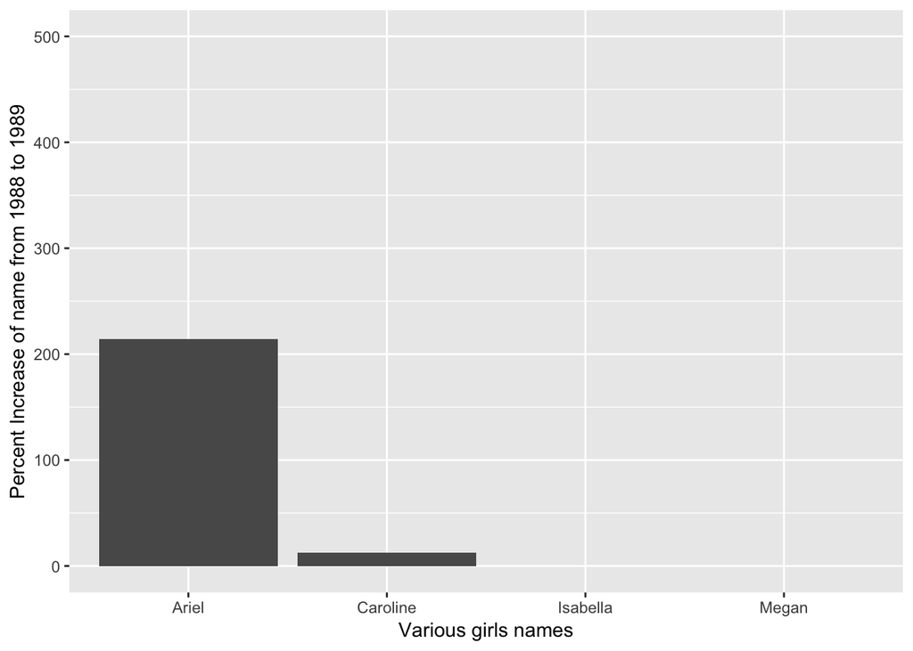

```r
Ariels1989 <- filter(babynames, year == 1989) %>% mutate(isAriel = str_detect(name, "Ar[ie]")) %>% filter (isAriel == TRUE & sex == "F")

percent_incAriel <- ((sum(Ariels1989$n) / sum(Ariels1988$n)) * 100) - 100
#acheieved by taking the total number of ariels and its name variations in 1989, divided by that number in 1988, multiplying by 100 to get the percent, than subtracting 100 to get just the percent increase not total percent


Carolines1988  <- filter(babynames, year == 1988) %>% mutate(isCaroline = str_detect(name, "Carol[iy]")) %>% filter (isCaroline == TRUE & sex == "F")
Carolines1989  <- filter(babynames, year == 1989) %>% mutate(isCaroline = str_detect(name, "Carol[iy]")) %>% filter (isCaroline == TRUE & sex == "F")

percent_incCaroline <- ((sum(Carolines1989$n) / sum(Carolines1988$n)) * 100) - 100

Isabella1988  <- filter(babynames, year == 1988) %>% mutate(isIsabella = str_detect(name, "Isabel[la.]")) %>% filter (isIsabella == TRUE & sex == "F")
Isabella1989  <- filter(babynames, year == 1989) %>% mutate(isIsabella = str_detect(name, "Isabel[la.]")) %>% filter (isIsabella == TRUE & sex == "F")

percent_incIsabella <- ((sum(Isabella1988$n) / sum(Isabella1989$n)) * 100) - 100

Megan1988  <- filter(babynames, year == 1988) %>% mutate(isMegan = str_detect(name, "Meg[ha]")) %>% filter (isMegan == TRUE & sex == "F")
Megan1989  <- filter(babynames, year == 1989) %>% mutate(isMegan = str_detect(name, "Meg[ha]")) %>% filter (isMegan == TRUE & sex == "F")

percent_incMegan <- ((sum(Megan1988$n) / sum(Megan1989$n)) * 100) - 100


#
#creating tibble with
x = c("Ariel", "Caroline", "Isabella", "Megan")
graphData <- as.tibble(x)
 y = c(percent_incAriel, percent_incCaroline, percent_incIsabella, percent_incMegan)

ggplot(data = graphData, aes(x = x, y = y)) + geom_bar(stat = "identity") + ylim(0, 500) + ylab("Percent Increase of name from 1988 to 1989") + xlab("Various girls names")
```

# Individual

### Lauren

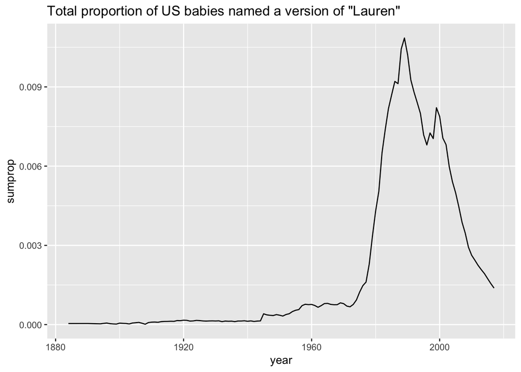

```r
babynamesLauren <- babynamesPersonal
babynamesL<-(babynames::babynames)
Lauren <- filter(babynamesL,str_detect(babynamesL$name, "L[ao][^ie]r[ey]n+[^a]?$")) %>% group_by(year) %>% summarize(sumprop=sum(prop))

ggplot(data=Lauren) +
  geom_line(aes(x=year,y=sumprop)) +
  ggtitle("Total proportion of US babies named a version of \"Lauren\"")
```

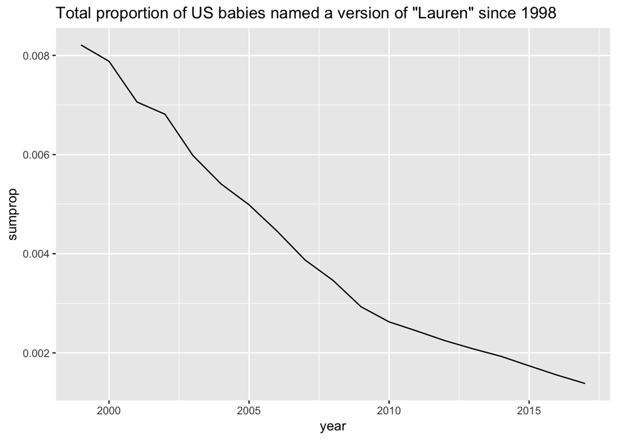

```r
Laurensincebirth <- filter(Lauren,year>1998)

ggplot(data=Laurensincebirth) +
  geom_line(aes(x=year,y=sumprop)) +
  ggtitle("Total proportion of US babies named a version of \"Lauren\" since 1998")
```

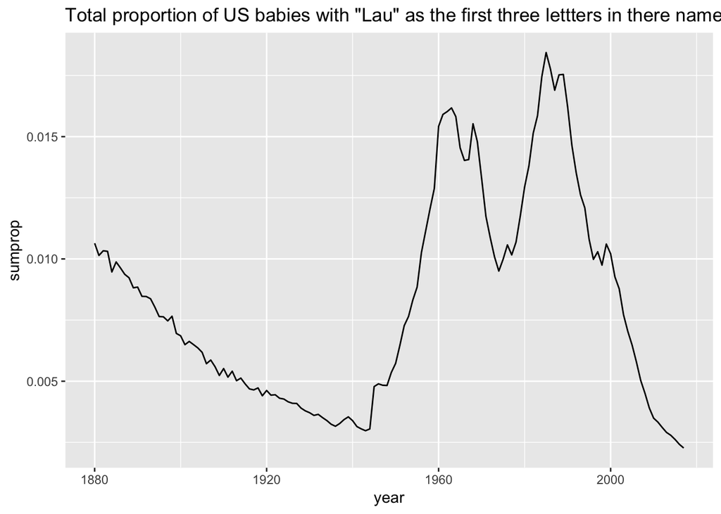

```r
  Lau <- filter(babynamesL,str_detect(babynamesL$name, "Lau")) %>% group_by(year) %>% summarize(sumprop=sum(prop))
ggplot(data=Lau) +
  geom_line(aes(x=year,y=sumprop)) +
  ggtitle("Total proportion of US babies with \"Lau\" as the first three lettters in there name")
```

From looking at the proportion of US babies named a version of “Lauren”, it is interesting to note the peak of people named “Lauren” occured before 1998, the year I was born. Since then, there has been a significant decrease in the number of people named Lauren. It would be interesting to investigate the same question, but separate the babies into male and female. The proportion of babies with a first name that starts with Lau, began to significantly rise near the 1950’s, and again, has significantly decreased since 1998.